# Cross-Validation and PSIS

Elizabeth King

Kevin Middleton

## Information criteria vs. Cross-validation

- Information equals “Surprise”
- Cross validation
  - Divide the data (*k* folds), refit models, out-of-sample prediction
  - Leave-one-out is the logical extreme
  - Review *Quantitative Methods* lecture 10-4

## Why not leave-one-out for Bayesian models?

- Resample the model for every data point?
  - Hundreds or thousands of distributions
  - Time-intensive
- We need a LOO-CV approximation (Bürkner et al. 2021)
  - Which is also an approximation of expected log-predictive density (elpd)
  - Like AIC and WAIC are approximations

## PSIS-LOO-CV

Pareto-smoothed importance sampling (Vehtari et al. 2015, 2017)

- Determine the “importance” of each observation to the posterior
- “Unlikely” observations are more important than expected ones (more weight)
- Pareto-smoothing makes these estimates more reliable
- Math not critical to understand

## Naked Mole Rats

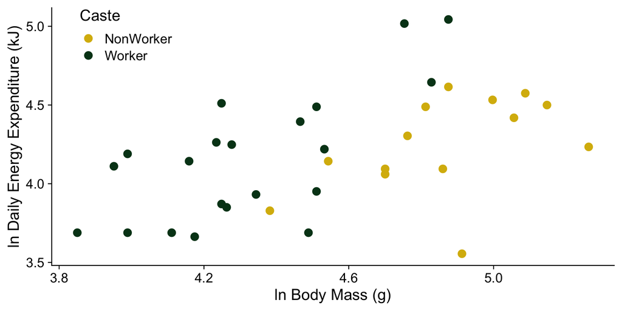

## Five models

1. Mean: grand mean (no body mass)
2. ANOVA: group means only (no body mass)
3. OLS regression: body mass only, no grouping
4. ANCOVA: intercepts varying
5. ANCOVA: slopes varying and intercepts varying

## 4: ANCOVA, intercepts varying

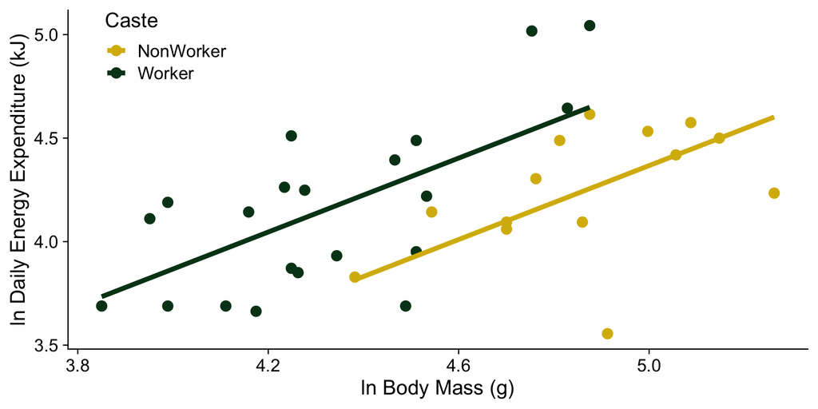

## 5: ANCOVA, intercepts and slopes vary

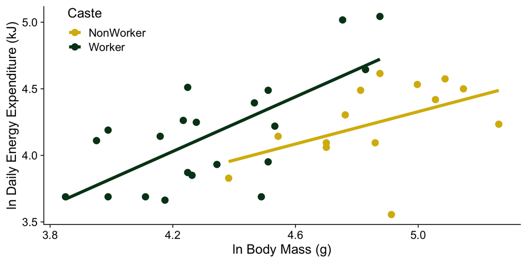

## PSIS-LOO-CV with `loo()`

Built-in diagnostics

- Very high weights can make PSIS-LOO-CV unreliable (Pareto $k$ estimates)
- These influential values are flagged by `loo()`
- Inspect with `loo::pareto_k_ids()`
- `reloo()` to refit problem obervations

## PSIS-LOO-CV with `loo()`

- `looic` functions like a WAIC or AIC

```r
loo(fm5)
```

```
Computed from 40000 by 35 log-likelihood matrix

         Estimate  SE
elpd_loo     -9.9 4.2
p_loo         4.0 1.0
looic        19.8 8.4
------
Monte Carlo SE of elpd_loo is 0.0.

All Pareto k estimates are good (k < 0.5).
See help('pareto-k-diagnostic') for details.
```

## Adding PSIS-LOO-CV to a model

`add_criterion()` adds different criteria to models (WAIC, PSIS-LOO-CV)

```r
fm1 <- add_criterion(fm1, criterion = "loo")
fm2 <- add_criterion(fm2, criterion = "loo")
fm3 <- add_criterion(fm3, criterion = "loo")
fm4 <- add_criterion(fm4, criterion = "loo")
fm5 <- add_criterion(fm5, criterion = "loo")
```

Also do this if you want to save the model to an object for later use

## LOO compare

```r
loo_compare(fm1, fm2, fm3, fm4, fm5, criterion = "loo")
```

```
    elpd_diff se_diff
fm4  0.0       0.0
fm5 -0.1       0.6
fm3 -2.6       2.4
fm1 -7.0       3.9
fm2 -7.8       3.9
```

## LOO model weights

```r
model_weights(fm1, fm2, fm3, fm4, fm5, weights = "loo") |>
  as.data.frame() |>
  knitr::kable(col.names = "Weight", digits = 4)
```

## LOO model weights

|  | Weight |
| --- | --- |
| fm1 | 0.0005 |
| fm2 | 0.0002 |
| fm3 | 0.0390 |
| fm4 | 0.5063 |
| fm5 | 0.4540 |

## References

Bürkner, P.-C., J. Gabry, and A. Vehtari. 2021. [Efficient Leave-One-Out Cross-Validation for Bayesian Non-Factorized Normal and Student-t Models](https://doi.org/10.1007/s00180-020-01045-4). *Comput. Stat.* 36:1243–1261.

Vehtari, A., A. Gelman, and J. Gabry. 2017. [Practical Bayesian Model Evaluation Using Leave-One-Out Cross-Validation and WAIC](https://doi.org/10.1007/s11222-016-9696-4). *Stat. Comput.* 27:1413–1432.

Vehtari, A., D. Simpson, A. Gelman, Y. Yao, and J. Gabry. 2015. [Pareto Smoothed Importance Sampling](http://arxiv.org/abs/1507.02646).